# Notebook

```python
import pandas as pd
import matplotlib.pyplot as plt
%matplotlib inline
```

```python
data = pd.read_csv('dataq4.csv')
data =pd.DataFrame(data)
```

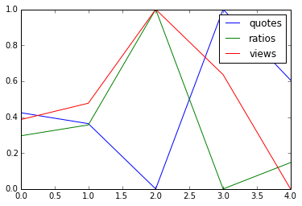

```python
data['Ratio'] = ((data.Views/data.Quotes))
plt.plot((data.Quotes-min(data.Quotes))/(max(data.Quotes)-min(data.Quotes)))
plt.plot((data.Ratio-min(data.Ratio))/(max(data.Ratio)-min(data.Ratio)))
# plt.plot(data.Ratio)
plt.plot((data.Views-min(data.Views))/(max(data.Views)-min(data.Views)))
plt.hold()
plt.legend(['quotes','ratios','views'])
```

```python
data
baseline= 32
data['change']= ((data.Quotes - baseline)/baseline)*100
data
```

|  | Bucket | Quotes | Views | Ratio | change |
| --- | --- | --- | --- | --- | --- |
| 0 | Baseline | 32 | 595 | 18.593750 | 0.000 |
| 1 | Variation 1 | 30 | 599 | 19.966667 | -6.250 |
| 2 | Variation 2 | 18 | 622 | 34.555556 | -43.750 |
| 3 | Variation 3 | 51 | 606 | 11.882353 | 59.375 |
| 4 | Variation 4 | 38 | 578 | 15.210526 | 18.750 |

## Response

Since little to no information is given concerning the variations, it is probably best to assume little to nothing about them as making you can rationalize very poor decisions. From the question and 'view' given it seems best to optimize for the highest amount of 'quotes' as that is when Acme Corp makes money.

## Questions

For questions about the data, I'd say its important to know if to send a quote is a flat fee as perhaps a \$100 personal trainer would be more reluctant to send a quote if it costs \$10 than a \$1000 catering service. One is paying 10% of his potential gain where as the other is paying 1%. I think it'd be beneficial to incorporate some refund system for quotes that do not get accepted (maybe 50% or something) to encourage more service providers to send a quote.

I think it would be interesting to collect more features and broader data set to actually do some algorithims or modeling on it such as a random forest or SVM to predict whether a view will turn into a quote but at this point with so few features it would be equivalent to applying a random number to some threshold which is uninteresting and assuming.